# Solutions_Ramon_Schildknecht_RTP Excercise Sheet - Series 5

[Ramon Schildknecht](https://www.linkedin.com/in/ramon-schildknecht-36301756/)

```r
library(tseries)
library(tidyverse)
library(magrittr)
library(plotly)
library(timetk)
library(lubridate)
library(pracma)
library(fma)
library(forecast)
library(fpp)
library(car)
library(astsa)
library(dygraphs)
```

# Series 5

## Exercise 5.1 - Stationarity Rederal Reserve Board Production Index

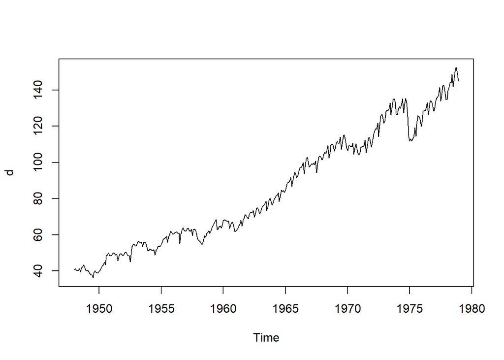

```r
d <- prodn
plot(d)
```

There is a clear trend recognisable.

There are several available options:

- Linear regression
- Backward difference
- Filtration

First guess: SARIMA could fit.

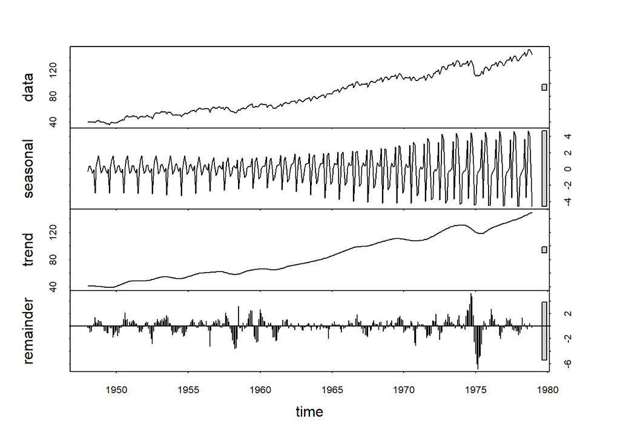

```r
d_decomposition <- stl(d, s.window = 12)
plot(d_decomposition)
```

```r
d_dygraph <- cbind(origin = d,
                   seasonality = d_decomposition$time.series[,"seasonal"],
                   trend = d_decomposition$time.series[,"trend"],
                   remainder = d_decomposition$time.series[,"remainder"])
dygraph(d_dygraph)
```

[interactive chart not shown]

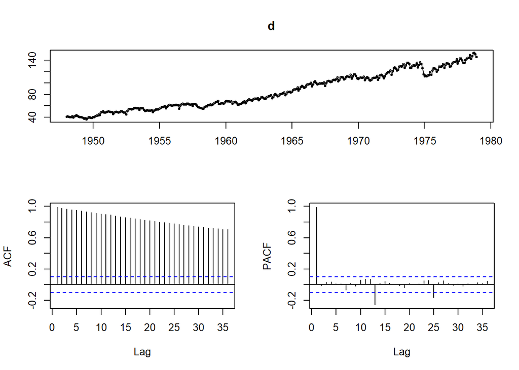

```r
# dygraph(d_dygraph[,"trend"])
tsdisplay(d)
```

```r
(d_sarima <- arima(d, order = c(1,1,1), seasonal = c(1, 1, 1)))
```

```
##
## Call:
## arima(x = d, order = c(1, 1, 1), seasonal = c(1, 1, 1))
##
## Coefficients:
##          ar1      ma1     sar1     sma1
##       0.5767  -0.2783  -0.0352  -0.6700
## s.e.  0.1178   0.1376   0.0664   0.0424
##
## sigma^2 estimated as 1.426:  log likelihood = -577.01,  aic = 1164.02
```

```r
(d_sarima <- arima(d, order = c(1,1,0), seasonal = c(1, 1, 1)))
```

```
##
## Call:
## arima(x = d, order = c(1, 1, 0), seasonal = c(1, 1, 1))
##
## Coefficients:
##          ar1     sar1     sma1
##       0.3299  -0.0471  -0.6722
## s.e.  0.0500   0.0656   0.0420
##
## sigma^2 estimated as 1.438:  log likelihood = -578.7,  aic = 1165.41
```

```r
(d_sarima <- arima(d, order = c(1,0,1), seasonal = c(1, 1, 1)))
```

```
##
## Call:
## arima(x = d, order = c(1, 0, 1), seasonal = c(1, 1, 1))
##
## Coefficients:
##          ar1     ma1     sar1     sma1
##       0.9936  0.2623  -0.0503  -0.6809
## s.e.  0.0056  0.0436   0.0650   0.0414
##
## sigma^2 estimated as 1.47:  log likelihood = -585.68,  aic = 1181.36
```

```r
(d_sarima <- arima(d, order = c(1,1,1), seasonal = c(0, 1, 1))) # improved aic
```

```
##
## Call:
## arima(x = d, order = c(1, 1, 1), seasonal = c(0, 1, 1))
##
## Coefficients:
##          ar1      ma1     sma1
##       0.5827  -0.2857  -0.6831
## s.e.  0.1160   0.1357   0.0331
##
## sigma^2 estimated as 1.428:  log likelihood = -577.15,  aic = 1162.3
```

```r
(d_sarima <- arima(d, order = c(1,1,1), seasonal = c(0, 0, 1)))
```

```
##
## Call:
## arima(x = d, order = c(1, 1, 1), seasonal = c(0, 0, 1))
##
## Coefficients:
##          ar1     ma1   sma1
##       0.0085  0.0578  0.639
## s.e.  0.4972  0.4922  0.036
##
## sigma^2 estimated as 4.024:  log likelihood = -787.85,  aic = 1583.69
```

```r
(d_sarima <- arima(d, order = c(1,1,1), seasonal = c(0, 2, 0)))
```

```
##
## Call:
## arima(x = d, order = c(1, 1, 1), seasonal = c(0, 2, 0))
##
## Coefficients:
##          ar1      ma1
##       0.7053  -0.4038
## s.e.  0.0757   0.0935
##
## sigma^2 estimated as 6.203:  log likelihood = -812.99,  aic = 1631.97
```

```r
(d_sarima <- arima(d, order = c(1,1,1), seasonal = c(0, 1, 3))) # improved aic
```

```
##
## Call:
## arima(x = d, order = c(1, 1, 1), seasonal = c(0, 1, 3))
##
## Coefficients:
##          ar1      ma1     sma1     sma2    sma3
##       0.5706  -0.2608  -0.7432  -0.1397  0.2782
## s.e.  0.1119   0.1295   0.0535   0.0647  0.0526
##
## sigma^2 estimated as 1.314:  log likelihood = -564.24,  aic = 1140.48
```

```r
(d_sarima <- arima(d, order = c(1,1,1), seasonal = c(0, 1, 4)))
```

```
##
## Call:
## arima(x = d, order = c(1, 1, 1), seasonal = c(0, 1, 4))
##
## Coefficients:
##          ar1      ma1     sma1     sma2    sma3    sma4
##       0.5707  -0.2617  -0.7401  -0.1411  0.2647  0.0167
## s.e.  0.1123   0.1301   0.0544   0.0661  0.0675  0.0520
##
## sigma^2 estimated as 1.314:  log likelihood = -564.19,  aic = 1142.37
```

The best result performs the following SARIMA model:  
arima(d, order = c(1,1,1), seasonal = c(0, 1, 3)))

## Exercise 5.2 - sunspot data & AR model

Preparation

```r
lsunspot100 <- window(log(sunspotarea), start = 1875, end = 1974)
fit_ar10 <- arima(lsunspot100, order = c(10, 0, 0))
```

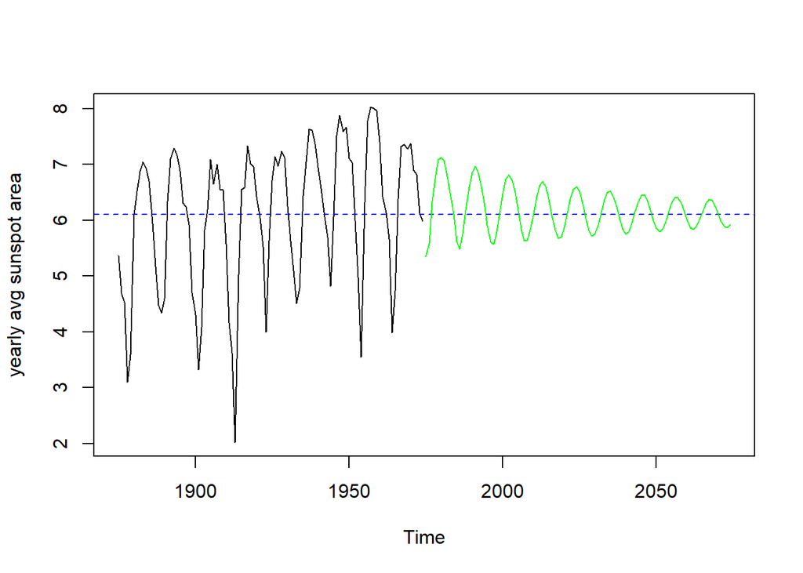

```r
lsunspot100 <- window(log(sunspotarea), start = 1875, end = 1974)
fit_ar10 <- arima(lsunspot100, order = c(10, 0, 0))
predictions <- predict(fit_ar10, n.ahead = 100)
plot(lsunspot100, xlim = c(1875, 2074), ylab = "yearly avg sunspot area")
abline(h = fit_ar10$coef["intercept"], lty = 2, col = "blue")
lines(predictions$pred, col = "green")
```

The predictions show a damped sinusoid towards the global mean. Every cycle reduces the scattering of the predicted points.

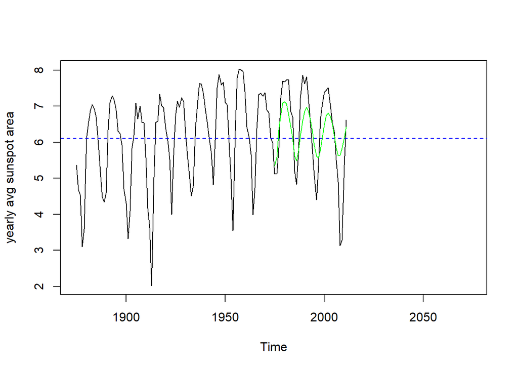

```r
lsunspot100_2 <- window(log(sunspotarea), start = 1875, end = 2011)
fit_ar10_2 <- arima(ts(lsunspot100_2, start = 1875, end = 1974), order = c(10, 0, 0))
predictions_2 <- predict(fit_ar10_2, n.ahead = 37)
plot(lsunspot100_2, xlim = c(1875, 2074), ylab = "yearly avg sunspot area")
abline(h = fit_ar10_2$coef["intercept"], lty = 2, col = "blue")
lines(predictions_2$pred, col = "green")
```

```r
cat("Mean squared forecasting error: ", (msfe <- (sum((as.numeric(tail(lsunspot100_2, 37)) - as.numeric(predictions_2$pred))^2))/length(lsunspot100_2)))
```

```
## Mean squared forecasting error:  0.2041178
```

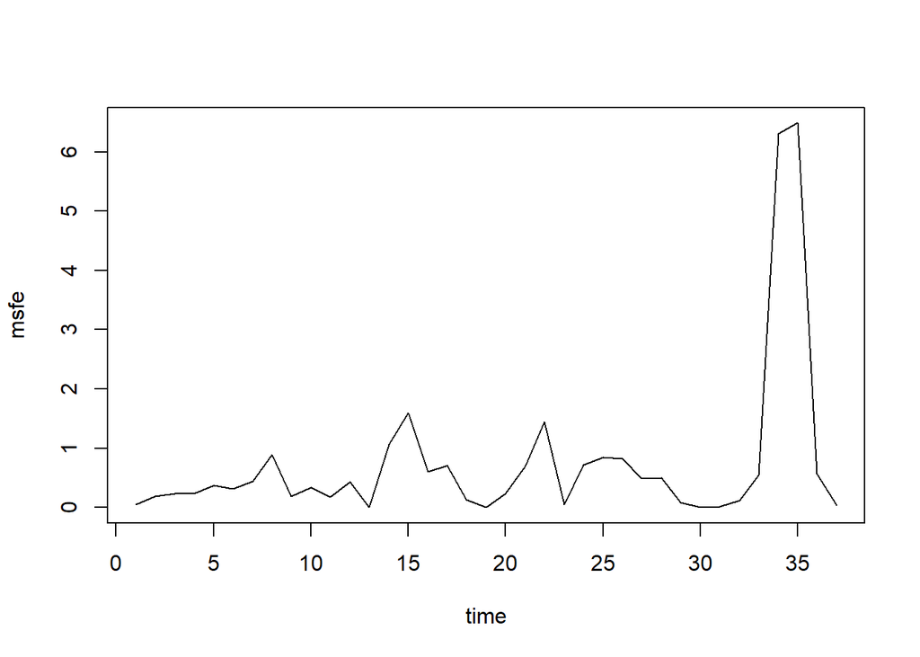

```r
plot((as.numeric(tail(lsunspot100_2, 37)) - as.numeric(predictions_2$pred))^2, type = "l",  xlab = "time", ylab = "msfe")
```

The predictions getting more inaccurate over time The mean squared forecasting error (msfe) is about 0.2. The msfe is very high at the end because there is a outlier in the time series. One could expect that the model will not fit very well for future predicted points.

## Exercise 5.3 - SARIMA with airplane data

data preparation

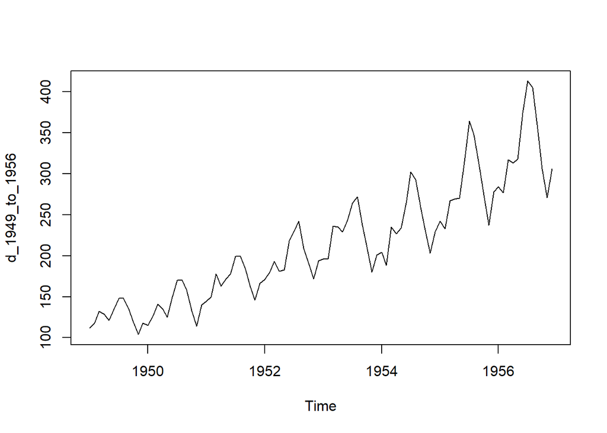

```r
d <- AirPassengers
d_1949_to_1956 <- window(d, end = c(1956, 12))
plot(d_1949_to_1956) # seasonality seems to be 12 months
```

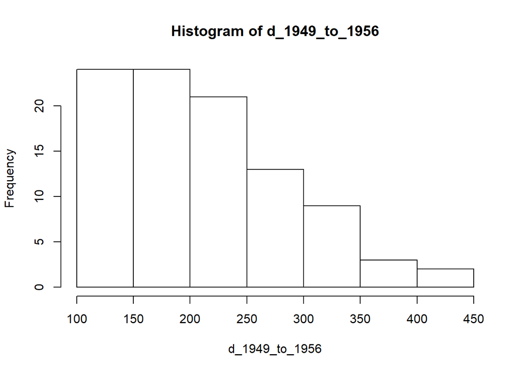

```r
hist(d_1949_to_1956)
```

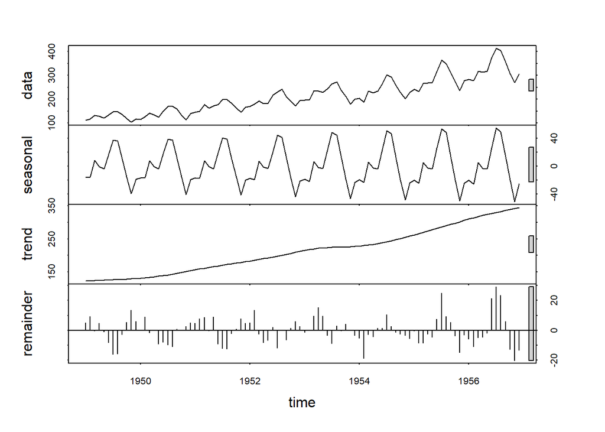

```r
plot(stl(d_1949_to_1956, s.window = 12))
```

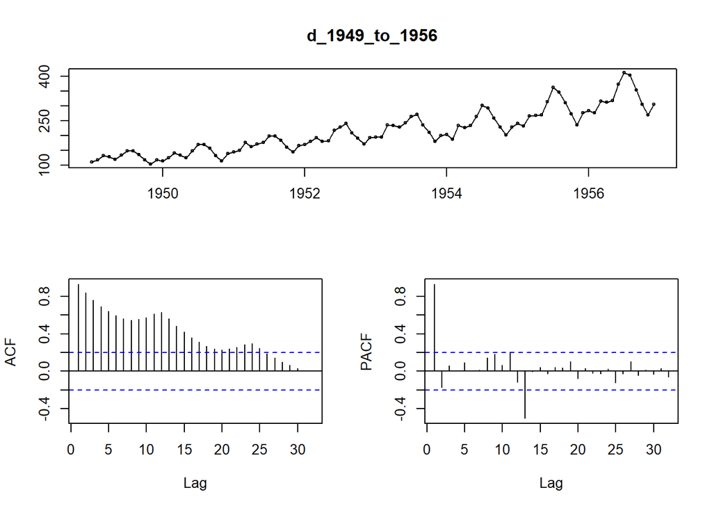

```r
tsdisplay(d_1949_to_1956)
```

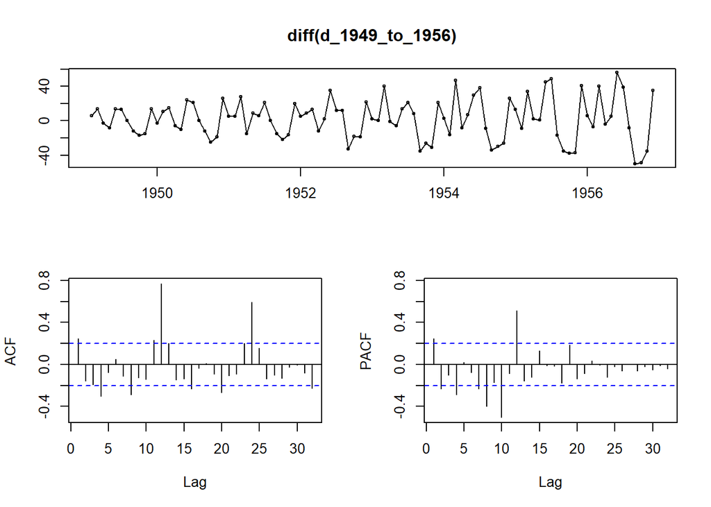

```r
tsdisplay(diff(d_1949_to_1956))
```

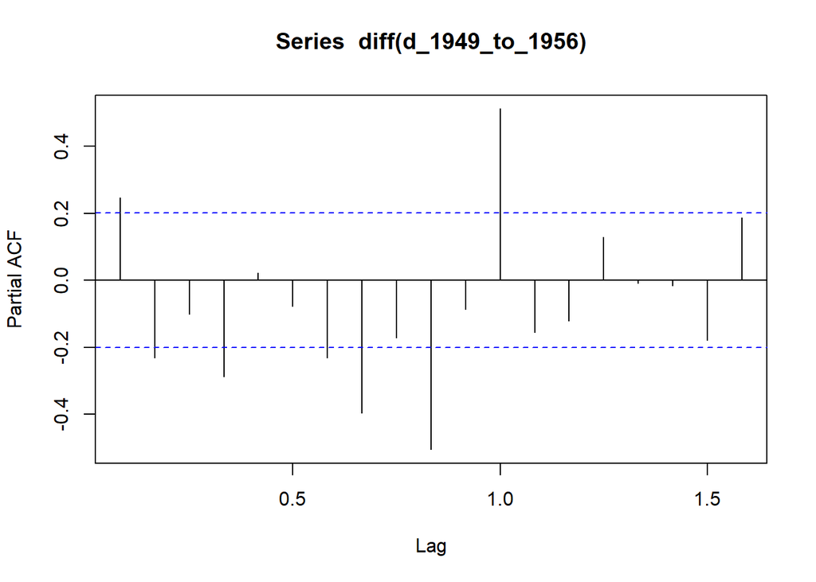

```r
pacf(diff(d_1949_to_1956))
```

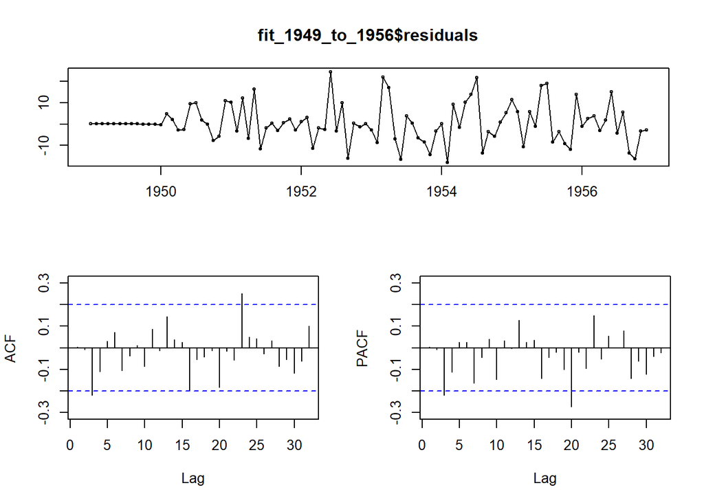

```r
d_1949_to_1956_arima_coefficients <- auto.arima(d_1949_to_1956, ic = "aic")
d_1949_to_1956_arima_coefficients_2 <- auto.arima(d_1949_to_1956, ic = "bic")
d_1949_to_1956_arima_coefficients_3 <- auto.arima(d_1949_to_1956, ic = "aicc")
fit_1949_to_1956 <- arima(d_1949_to_1956, order = c(1, 1, 0), seasonal = c(1, 1, 0))
tsdisplay(fit_1949_to_1956$residuals)
```

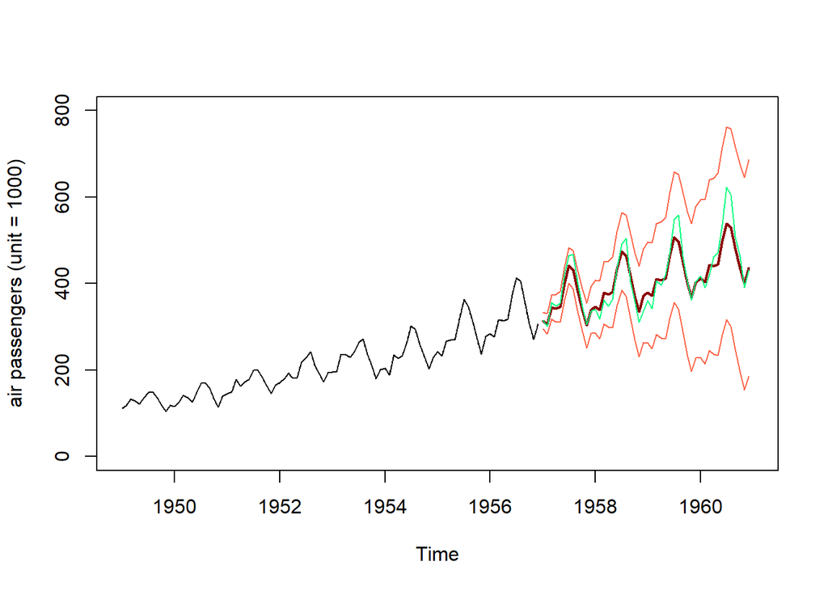

```r
predictions <- predict(fit_1949_to_1956, n.ahead = 48) # residuals looking good

plot(d_1949_to_1956, lty = 3, xlim = c(1949, 1961), ylim = c(0, 800), ylab = "air passengers (unit = 1000)")
lines(d_1949_to_1956, lwd = 1)
lines(predictions$pred, lwd = 2, col = "darkred")
lines(predictions$pred+predictions$se*1.96, col="tomato")
lines(predictions$pred-predictions$se*1.96, col="tomato")
lines(window(d, start = c(1957, 01), lwd = 2, end = c(1960, 12)), col = "springgreen")
```